# Chapter 7 - LME analysis of Mode and Nuclear Contours: l_f0

### LME model analysis using reduced model and removing outliers (|residual|>3.4)

Running model again but trimming rows with |residual| > 3.4 (as per Baayen 2008: 279-282).

NB a value of 3.4 was chosen as this removes the minimum number of outliers without leading to singularity errors while at the same time providing a more reasonable distribution or residuals.

```
## Linear mixed model fit by REML. t-tests use Satterthwaite's method [
## lmerModLmerTest]
## Formula: formula(cur_equation)
##    Data: m_corpus.trimmed
## Control:
## lmerControl(optimizer = "optimx", calc.derivs = FALSE, optCtrl = list(method = "nlminb",
##     starttests = FALSE, kkt = FALSE))
##
## REML criterion at convergence: 2097.4
##
## Scaled residuals:
##     Min      1Q  Median      3Q     Max
## -3.2509 -0.5725 -0.0617  0.5417  3.5243
##
## Random effects:
##  Groups   Name        Variance Std.Dev. Corr
##  speaker  (Intercept) 8.267577 2.87534
##           modeMWH     0.950946 0.97516   0.10
##           modeMYN     0.900354 0.94887   0.30 -0.21
##           modeMDQ     3.689857 1.92090   0.46 -0.53  0.14
##  prompt   (Intercept) 0.001231 0.03509
##  Residual             1.292768 1.13700
## Number of obs: 635, groups:  speaker, 11; prompt, 3
##
## Fixed effects:
##             Estimate Std. Error       df t value Pr(>|t|)
## (Intercept)  87.4293     1.0996   9.8362  79.512 3.81e-15 ***
## modeMWH       0.1018     0.3202  10.0412   0.318 0.756974
## modeMYN       1.7370     0.3127   9.9499   5.554 0.000247 ***
## modeMDQ       2.9843     0.5939   9.9665   5.025 0.000523 ***
## fin_phonL%    0.5942     0.1702 222.2080   3.491 0.000581 ***
## genderM      -9.2351     1.4715   9.0772  -6.276 0.000140 ***
## ---
## Signif. codes:  0 '***' 0.001 '**' 0.01 '*' 0.05 '.' 0.1 ' ' 1
##
## Correlation of Fixed Effects:
##            (Intr) modMWH modMYN modMDQ fn_pL%
## modeMWH     0.050
## modeMYN     0.191 -0.101
## modeMDQ     0.343 -0.432  0.166
## fin_phonL% -0.047  0.016 -0.010 -0.015
## genderM    -0.609  0.001 -0.001 -0.003  0.043
```

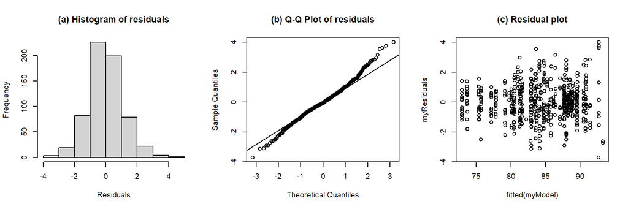

```
## Type III Analysis of Variance Table with Satterthwaite's method
##          Sum Sq Mean Sq NumDF   DenDF F value    Pr(>F)
## mode     73.275  24.425     3   9.938  18.894 0.0001980 ***
## fin_phon 15.754  15.754     1 222.208  12.186 0.0005805 ***
## gender   50.917  50.917     1   9.077  39.386 0.0001399 ***
## ---
## Signif. codes:  0 '***' 0.001 '**' 0.01 '*' 0.05 '.' 0.1 ' ' 1
```

```
## Check_singularity(temp_mdl.trimmed, tolerance = 1e-05 --> FALSE
```

Data trimmed from model

| speaker | gender | mode | prompt | phr_phon | l_f0 | l_f0_z |
| --- | --- | --- | --- | --- | --- | --- |
| F5 | F | MDQ | 2 | ^[% (*) L*H %] | 97.40 | 1.551305 |
| F5 | F | MDQ | 2 | ^[% (*) L*H %] | 98.39 | 1.844899 |
| F5 | F | MDQ | 3 | % (*) L*^[H] % | 86.99 | -1.535884 |
| F5 | F | MDQ | 3 | % (*) L*^[H L%] | 87.62 | -1.349051 |

- Distribution of residuals is more reasonable after removing outliers.
- Trimming further leads to convergence error.

### Final model: `l_f0 ~ mode + fin_phon + gender + (1 + mode | speaker) + (1 | prompt)`

#### Analysis of model

Intercept and slopes of fixed effects: l_f0 ~ mode + fin_phon + gender + (1 + mode | speaker) + (1 | prompt)

| term | estimate | std.error | 2.5% CI | 97.5% CI | t.value | df | p.value | p.adjusted |
| --- | --- | --- | --- | --- | --- | --- | --- | --- |
| (Intercept) | 87.419 | 1.103 | 85.257 | 89.581 | 79.261 | 9.89 | 0.0000e+00 | 0.0000e+00 |
| modeMWH | 0.103 | 0.320 | -0.523 | 0.730 | 0.323 | 10.05 | 0.7535 | 0.9999 |
| modeMYN | 1.735 | 0.313 | 1.122 | 2.349 | 5.548 | 9.95 | 2.0000e-04 | 0.0015 |
| modeMDQ | 2.979 | 0.592 | 1.819 | 4.139 | 5.032 | 9.96 | 5.0000e-04 | 0.0031 |
| fin_phonL% | 0.619 | 0.184 | 0.257 | 0.980 | 3.355 | 460.65 | 9.0000e-04 | 0.0052 |
| genderM | -9.216 | 1.477 | -12.111 | -6.322 | -6.241 | 9.08 | 1.0000e-04 | 9.0000e-04 |

Conditional and marginal R<sup>2</sup> of model

| R2_conditional | R2_marginal | optional |
| --- | --- | --- |
| 0.96 | 0.64 | FALSE |

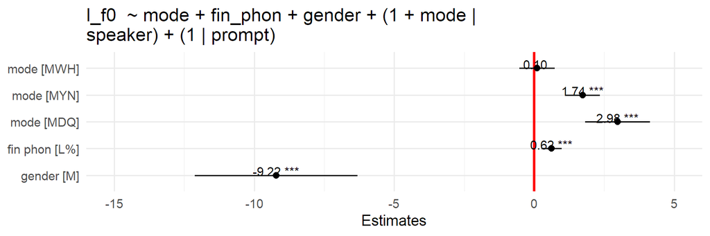

#### Summary of intercepts

b0 for l_f0 ~ mode + fin_phon + gender + (1 + mode | speaker) + (1 | prompt)

| intercept | estimate | std.error | 2.5% CI | 97.5% CI | t.value | df | p.value | p.adjusted | signif. (adj.) |
| --- | --- | --- | --- | --- | --- | --- | --- | --- | --- |
| modeMDC | 87.419 | 1.103 | 85.257 | 89.581 | 79.261 | 9.89 | 0.0000e+00 | 0.0000e+00 | p<0.001 |
| modeMWH | 87.522 | 1.164 | 85.242 | 89.803 | 75.221 | 11.01 | 0.0000e+00 | 0.0000e+00 | p<0.001 |
| modeMYN | 89.155 | 1.201 | 86.800 | 91.509 | 74.207 | 9.06 | 0.0000e+00 | 0.0000e+00 | p<0.001 |
| modeMDQ | 90.398 | 1.417 | 87.621 | 93.175 | 63.794 | 11.06 | 0.0000e+00 | 0.0000e+00 | p<0.001 |

#### Summary of pairwise comparisons

b1 for l_f0 ~ mode + fin_phon + gender + (1 + mode | speaker) + (1 | prompt)

| intercept | slope | estimate | std.error | 2.5% CI | 97.5% CI | t.value | df | p.value | p.adjusted | signif. (adj.) |
| --- | --- | --- | --- | --- | --- | --- | --- | --- | --- | --- |
| modeMDC | modeMWH | 0.103 | 0.320 | -0.523 | 0.730 | 0.323 | 10.05 | 0.7535 | 0.9999 |  |
| modeMDC | modeMYN | 1.735 | 0.313 | 1.122 | 2.349 | 5.548 | 9.95 | 2.0000e-04 | 0.0015 | p<0.01 |
| modeMDC | modeMDQ | 2.979 | 0.592 | 1.819 | 4.139 | 5.032 | 9.96 | 5.0000e-04 | 0.0031 | p<0.01 |
| modeMWH | modeMYN | 1.632 | 0.471 | 0.710 | 2.555 | 3.468 | 10.00 | 0.006 | 0.0362 | p<0.05 |
| modeMWH | modeMDQ | 2.876 | 0.787 | 1.334 | 4.418 | 3.656 | 10.04 | 0.0044 | 0.0264 | p<0.05 |
| modeMYN | modeMDQ | 1.244 | 0.622 | 0.023 | 2.464 | 1.998 | 10.05 | 0.0735 | 0.4412 |  |